# SSA 3 ANOVA

SB, LdW, RdM

2026-10-28

This example documents the effect of efficiency gain (better P-values) by adding a factor to an ANOVA. Experimental data is analyzed. Blood glucose is measured (`outcome`), the experiment is blocked by sex (`sex`) and there are two randomization groups (`rand`).

# Data

```r
data(blockedcrt)
data <- blockedcrt
```

# Question 1 (illustration)

## a

Visualize the outcome for the two different randomization groups.

**fillin**:

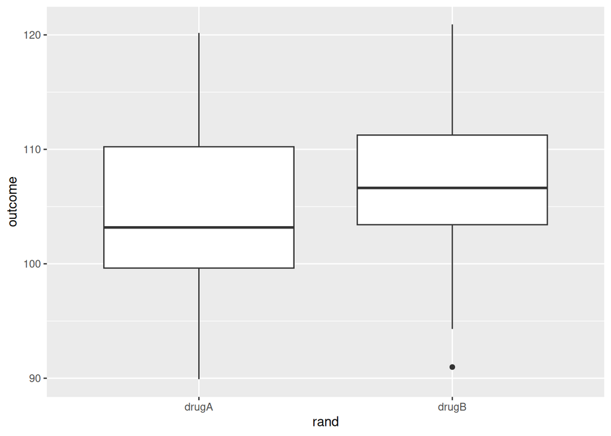

```r
ggplot(data, mapping = aes(x = rand, y = outcome)) +
  geom_boxplot()
```

## b

Visualize the outcome for the two different sex groups.

**fillin**:

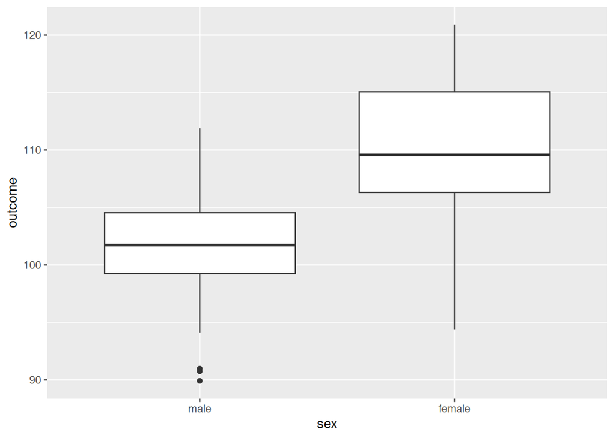

```r
ggplot(data, mapping = aes(x = sex, y = outcome)) +
  geom_boxplot()
```

# Question 2 (one-way ANOVA)

## a

Conduct a one-way ANOVA for the variable `rand`, use the function `aov`.

**fillin**:

```r
summary(aov(outcome ~ rand, data))
```

```
##             Df Sum Sq Mean Sq F value Pr(>F)
## rand         1    137  137.19   2.758    0.1 .
## Residuals   98   4875   49.74
## ---
## Signif. codes:  0 '***' 0.001 '**' 0.01 '*' 0.05 '.' 0.1 ' ' 1
```

## b

Perform a post-hoc analysis for rand. A post-hoc analysis identifies which particular levels of a factor actually differ from each other. This can be done by performing pair-wise t-tests. What is your interpretation?

**fillin**:

```r
t.test(outcome ~ rand, data)
```

```
##
##  Welch Two Sample t-test
##
## data:  outcome by rand
## t = -1.6607, df = 95.268, p-value = 0.1001
## alternative hypothesis: true difference in means between group drugA and group drugB is not equal to 0
## 95 percent confidence interval:
##  -5.1428764  0.4577132
## sample estimates:
## mean in group drugA mean in group drugB
##            104.6764            107.0190
```

It is also possible to analyze the same comparison using a linear regression, which is equivalent.

```r
summary(lm(outcome ~ rand, data))
```

```
##
## Call:
## lm(formula = outcome ~ rand, data = data)
##
## Residuals:
##      Min       1Q   Median       3Q      Max
## -16.0408  -4.7889  -0.8408   4.6267  15.4962
##
## Coefficients:
##             Estimate Std. Error t value Pr(>|t|)
## (Intercept) 104.6764     0.9974 104.945   <2e-16 ***
## randdrugB     2.3426     1.4106   1.661      0.1 .
## ---
## Signif. codes:  0 '***' 0.001 '**' 0.01 '*' 0.05 '.' 0.1 ' ' 1
##
## Residual standard error: 7.053 on 98 degrees of freedom
## Multiple R-squared:  0.02737,    Adjusted R-squared:  0.01745
## F-statistic: 2.758 on 1 and 98 DF,  p-value: 0.09997
```

# Question 3

## a

**fillin**:

```r
summary(aov(outcome ~ rand + sex, data))
```

```
##             Df Sum Sq Mean Sq F value   Pr(>F)
## rand         1  137.2   137.2   4.408   0.0384 *
## sex          1 1856.2  1856.2  59.642 1.04e-11 ***
## Residuals   97 3018.8    31.1
## ---
## Signif. codes:  0 '***' 0.001 '**' 0.01 '*' 0.05 '.' 0.1 ' ' 1
```

Factor `rand` is now significant. The correspond linear regression show roughly the same regression coefficient as in the previous analysis (2.3). Factor sex is highly significant. An important difference is that this second analysis shows a lower P-value for rand. The explanation is that variable sex explains a large part of the total variation, making the comparison of the randomization groups is now more efficient.

## b

Perform a post-hoc analysis for factor rand and sex. What is your interpretation?

**fillin**:

```r
summary(lm(outcome ~ rand + sex, data))
```

```
##
## Call:
## lm(formula = outcome ~ rand + sex, data = data)
##
## Residuals:
##      Min       1Q   Median       3Q      Max
## -14.5737  -3.0646  -0.1674   3.7221  11.1879
##
## Coefficients:
##             Estimate Std. Error t value Pr(>|t|)
## (Intercept) 100.3681     0.9663 103.873  < 2e-16 ***
## randdrugB     2.3426     1.1157   2.100   0.0384 *
## sexfemale     8.6167     1.1157   7.723 1.04e-11 ***
## ---
## Signif. codes:  0 '***' 0.001 '**' 0.01 '*' 0.05 '.' 0.1 ' ' 1
##
## Residual standard error: 5.579 on 97 degrees of freedom
## Multiple R-squared:  0.3977, Adjusted R-squared:  0.3853
## F-statistic: 32.03 on 2 and 97 DF,  p-value: 2.093e-11
```

# Question 4

In an experiment a so-called power balance band (https://youtu.be/6gIMxjr3n5U) was tested with three tests (strength: abduction, balance: balance on a ball, flexibility: stretching). We are only going to look at a few variables, for one of them (LengthTertiles) some changes have to be made, see below.

```r
data(powerband)
dataset <- powerband

dataset$LengthTertiles = factor(dataset$LengthTertiles)
dataset$LengthTertiles[which(dataset$LengthTertiles == 1)] = NA
```

## a

Analyze the dataset with a two-way ANOVA. Use the variable abductie11 (first abduction strength measurement) as your outcome. Use `LengthTertiles` (body height devided into three categories) and sex (`Sex`) as factors in your ANOVA. Which factors have a significant influence?

**fillin**:

```r
summary(aov(abductie11 ~ LengthTertiles + Sex, dataset))
```

```
##                Df Sum Sq Mean Sq F value   Pr(>F)
## LengthTertiles  2  13183    6591   5.443  0.00708 **
## Sex             1  42204   42204  34.853 2.58e-07 ***
## Residuals      53  64180    1211
## ---
## Signif. codes:  0 '***' 0.001 '**' 0.01 '*' 0.05 '.' 0.1 ' ' 1
## 38 observations deleted due to missingness
```

## b

Add an interaction between `LengthTertiles` and `Sex`, repeat the analysis. What are the degree of freedoms for the interaction? Why do you see this number?

**fillin**:

```r
summary(aov(abductie11 ~ LengthTertiles * Sex, dataset))
```

```
##                    Df Sum Sq Mean Sq F value   Pr(>F)
## LengthTertiles      2  13183    6591   6.664  0.00268 **
## Sex                 1  42204   42204  42.669 2.98e-08 ***
## LengthTertiles:Sex  2  13735    6868   6.943  0.00215 **
## Residuals          51  50445     989
## ---
## Signif. codes:  0 '***' 0.001 '**' 0.01 '*' 0.05 '.' 0.1 ' ' 1
## 38 observations deleted due to missingness
```

The factor `LengthTertiles` has three possible values (groups). One of the groups is the reference group with which the other two groups are compared. This number (2) is the degrees of freedom.

## c

Is the interaction significant? What is your interpretation?